# Credit Card Data Analysis for Business Optimization

### SUMMARY:-

To analyze comprehensive customer data to extract actionable insights that can enhance business strategies, improve customer satisfaction, optimize credit risk management, and drive revenue growth.

## Dataset info:-

The dataset contains various columns representing customer demographics, financial details, transaction history, and engagement metrics. Key columns include: credit Card_Category,Annual_Fees,Qtr,Credit_Limit,Total_Trans_Amt,Use Chip,Exp Type,Interest_Earned,Gender,Education_Level,Customer_Job ,Income,Revenue.

## Business Problem :

Customer Segmentation and Targeting Objective: Identify distinct customer segments to tailor marketing strategies, improve customer engagement, and enhance revenue

### 1. IMPORTING REQUIRED LIABRIRES

```python
import numpy as np
import pandas as pd
import seaborn as sns
import matplotlib.ticker as mtick
import matplotlib.pyplot as plt
%matplotlib inline
import warnings
warnings.filterwarnings('ignore')
```

### 2. READ THE DATASET

```python
data=pd.read_excel(r"C:\Users\Dell\Desktop\creditcard.xlsx")
data
```

|  | Client_Num | Card_Category | Annual_Fees | Activation_30_Days | Customer_Acq_Cost | Week_Start_Date | Week_Num | Qtr | current_year | Credit_Limit | ... | Zipcode | Car_Owner | House_Owner | Personal_loan | contact | Customer_Job | Income | Revenue | Income-Category | Cust_SatisFemaleaction_Score |
| --- | --- | --- | --- | --- | --- | --- | --- | --- | --- | --- | --- | --- | --- | --- | --- | --- | --- | --- | --- | --- | --- |
| 0 | 708082083 | Blue | 200 | 0 | 87 | 2023-01-01 | Week-1 | Q1 | 2023 | 3544.0 | ... | 91750 | no | yes | no | unknown | BusinessMan | 202326 | 19742 | High-category | 3 |
| 1 | 708083283 | Blue | 445 | 1 | 108 | 2023-01-01 | Week-1 | Q1 | 2023 | 3421.0 | ... | 91750 | no | no | no | cellular | Selfemployee | 5225 | 1506 | low-category | 2 |
| 2 | 708084558 | Blue | 140 | 0 | 106 | 2023-01-01 | Week-1 | Q1 | 2023 | 8258.0 | ... | 91750 | yes | no | no | unknown | Selfemployee | 14235 | 1790 | low-category | 2 |
| 3 | 708085458 | Blue | 250 | 1 | 150 | 2023-01-01 | Week-1 | Q1 | 2023 | 1438.0 | ... | 91750 | no | no | no | cellular | Blue-collar | 45683 | 4426 | Medium-Category | 1 |
| 4 | 708086958 | Blue | 320 | 1 | 106 | 2023-01-01 | Week-1 | Q1 | 2023 | 3128.0 | ... | 91750 | yes | yes | no | cellular | BusinessMan | 59279 | 5694 | Medium-Category | 1 |
| ... | ... | ... | ... | ... | ... | ... | ... | ... | ... | ... | ... | ... | ... | ... | ... | ... | ... | ... | ... | ... | ... |
| 10103 | 827440458 | Blue | 125 | 0 | 43 | 2023-12-24 | Week-52 | Q4 | 2023 | 9524.0 | ... | 91750 | yes | no | no | cellular | Govt | 104552 | 9308 | High-category | 5 |
| 10104 | 827628408 | Blue | 195 | 1 | 84 | 2023-12-24 | Week-52 | Q4 | 2023 | 2165.0 | ... | 91750 | no | yes | yes | cellular | BusinessMan | 40188 | 4858 | Medium-Category | 5 |
| 10105 | 827691858 | Blue | 150 | 1 | 117 | 2023-12-24 | Week-52 | Q4 | 2023 | 7616.0 | ... | 91750 | yes | no | no | unknown | Selfemployee | 20071 | 2617 | low-category | 3 |
| 10106 | 827695683 | Blue | 340 | 1 | 106 | 2023-12-24 | Week-52 | Q4 | 2023 | 34516.0 | ... | 91750 | yes | yes | yes | Unknown | Selfemployee | 44903 | 4793 | Medium-Category | 5 |
| 10107 | 827703258 | Blue | 395 | 1 | 104 | 2023-12-24 | Week-52 | Q4 | 2023 | 13426.0 | ... | 91750 | no | yes | no | cellular | Selfemployee | 73655 | 5677 | High-category | 3 |

10108 rows × 34 columns

### 3. CHECK THE DATA

```python
data.columns
```

```
Index(['Client_Num', 'Card_Category', 'Annual_Fees', 'Activation_30_Days',
       'Customer_Acq_Cost', 'Week_Start_Date', 'Week_Num', 'Qtr',
       'current_year', 'Credit_Limit', 'Total_Revolving_Bal',
       'Total_Trans_Amt', 'Total_Trans_Vol', 'Avg_Utilization_Ratio',
       'Use Chip', 'Exp Type', 'Interest_Earned', 'Delinquent_Acc',
       'CustoMaleer_Age', 'Gender', 'Dependent_Count', 'Education_Level',
       'Material_Status', 'state_cd', 'Zipcode', 'Car_Owner', 'House_Owner',
       'Personal_loan', 'contact', 'Customer_Job', 'Income', 'Revenue',
       'Income-Category', 'Cust_SatisFemaleaction_Score'],
      dtype='object')
```

```python
data.dtypes
```

```
Client_Num                               int64
Card_Category                           object
Annual_Fees                              int64
Activation_30_Days                       int64
Customer_Acq_Cost                        int64
Week_Start_Date                 datetime64[ns]
Week_Num                                object
Qtr                                     object
current_year                             int64
Credit_Limit                           float64
Total_Revolving_Bal                      int64
Total_Trans_Amt                          int64
Total_Trans_Vol                          int64
Avg_Utilization_Ratio                  float64
Use Chip                                object
Exp Type                                object
Interest_Earned                          int64
Delinquent_Acc                           int64
CustoMaleer_Age                          int64
Gender                                  object
Dependent_Count                          int64
Education_Level                         object
Material_Status                         object
state_cd                                object
Zipcode                                  int64
Car_Owner                               object
House_Owner                             object
Personal_loan                           object
contact                                 object
Customer_Job                            object
Income                                   int64
Revenue                                  int64
Income-Category                         object
Cust_SatisFemaleaction_Score             int64
dtype: object
```

```python
data.info()
```

```
<class 'pandas.core.frame.DataFrame'>
RangeIndex: 10108 entries, 0 to 10107
Data columns (total 34 columns):
 #   Column                        Non-Null Count  Dtype
---  ------                        --------------  -----
 0   Client_Num                    10108 non-null  int64
 1   Card_Category                 10108 non-null  object
 2   Annual_Fees                   10108 non-null  int64
 3   Activation_30_Days            10108 non-null  int64
 4   Customer_Acq_Cost             10108 non-null  int64
 5   Week_Start_Date               10108 non-null  datetime64[ns]
 6   Week_Num                      10108 non-null  object
 7   Qtr                           10108 non-null  object
 8   current_year                  10108 non-null  int64
 9   Credit_Limit                  10108 non-null  float64
```

[output cut: 26 more lines]

```python
data.shape
```

```
(10108, 34)
```

```python
data.head()
```

|  | Client_Num | Card_Category | Annual_Fees | Activation_30_Days | Customer_Acq_Cost | Week_Start_Date | Week_Num | Qtr | current_year | Credit_Limit | ... | Zipcode | Car_Owner | House_Owner | Personal_loan | contact | Customer_Job | Income | Revenue | Income-Category | Cust_SatisFemaleaction_Score |
| --- | --- | --- | --- | --- | --- | --- | --- | --- | --- | --- | --- | --- | --- | --- | --- | --- | --- | --- | --- | --- | --- |
| 0 | 708082083 | Blue | 200 | 0 | 87 | 2023-01-01 | Week-1 | Q1 | 2023 | 3544.0 | ... | 91750 | no | yes | no | unknown | BusinessMan | 202326 | 19742 | High-category | 3 |
| 1 | 708083283 | Blue | 445 | 1 | 108 | 2023-01-01 | Week-1 | Q1 | 2023 | 3421.0 | ... | 91750 | no | no | no | cellular | Selfemployee | 5225 | 1506 | low-category | 2 |
| 2 | 708084558 | Blue | 140 | 0 | 106 | 2023-01-01 | Week-1 | Q1 | 2023 | 8258.0 | ... | 91750 | yes | no | no | unknown | Selfemployee | 14235 | 1790 | low-category | 2 |
| 3 | 708085458 | Blue | 250 | 1 | 150 | 2023-01-01 | Week-1 | Q1 | 2023 | 1438.0 | ... | 91750 | no | no | no | cellular | Blue-collar | 45683 | 4426 | Medium-Category | 1 |
| 4 | 708086958 | Blue | 320 | 1 | 106 | 2023-01-01 | Week-1 | Q1 | 2023 | 3128.0 | ... | 91750 | yes | yes | no | cellular | BusinessMan | 59279 | 5694 | Medium-Category | 1 |

5 rows × 34 columns

```python
data.tail()
```

|  | Client_Num | Card_Category | Annual_Fees | Activation_30_Days | Customer_Acq_Cost | Week_Start_Date | Week_Num | Qtr | current_year | Credit_Limit | ... | Zipcode | Car_Owner | House_Owner | Personal_loan | contact | Customer_Job | Income | Revenue | Income-Category | Cust_SatisFemaleaction_Score |
| --- | --- | --- | --- | --- | --- | --- | --- | --- | --- | --- | --- | --- | --- | --- | --- | --- | --- | --- | --- | --- | --- |
| 10103 | 827440458 | Blue | 125 | 0 | 43 | 2023-12-24 | Week-52 | Q4 | 2023 | 9524.0 | ... | 91750 | yes | no | no | cellular | Govt | 104552 | 9308 | High-category | 5 |
| 10104 | 827628408 | Blue | 195 | 1 | 84 | 2023-12-24 | Week-52 | Q4 | 2023 | 2165.0 | ... | 91750 | no | yes | yes | cellular | BusinessMan | 40188 | 4858 | Medium-Category | 5 |
| 10105 | 827691858 | Blue | 150 | 1 | 117 | 2023-12-24 | Week-52 | Q4 | 2023 | 7616.0 | ... | 91750 | yes | no | no | unknown | Selfemployee | 20071 | 2617 | low-category | 3 |
| 10106 | 827695683 | Blue | 340 | 1 | 106 | 2023-12-24 | Week-52 | Q4 | 2023 | 34516.0 | ... | 91750 | yes | yes | yes | Unknown | Selfemployee | 44903 | 4793 | Medium-Category | 5 |
| 10107 | 827703258 | Blue | 395 | 1 | 104 | 2023-12-24 | Week-52 | Q4 | 2023 | 13426.0 | ... | 91750 | no | yes | no | cellular | Selfemployee | 73655 | 5677 | High-category | 3 |

5 rows × 34 columns

```python
data.describe().T
```

|  | count | mean | min | 25% | 50% | 75% | max | std |
| --- | --- | --- | --- | --- | --- | --- | --- | --- |
| Client_Num | 10108.0 | 739010423.576771 | 708082083.0 | 713026683.0 | 717903745.5 | 772798945.5 | 827890758.0 | 36736228.859239 |
| Annual_Fees | 10108.0 | 291.849525 | 95.0 | 195.0 | 295.0 | 395.0 | 500.0 | 118.339384 |
| Activation_30_Days | 10108.0 | 0.574693 | 0.0 | 0.0 | 1.0 | 1.0 | 1.0 | 0.494414 |
| Customer_Acq_Cost | 10108.0 | 96.254056 | 40.0 | 79.0 | 95.0 | 112.0 | 172.0 | 25.768677 |
| Week_Start_Date | 10108 | 2023-06-27 23:17:07.146814464 | 2023-01-01 00:00:00 | 2023-03-26 00:00:00 | 2023-06-25 00:00:00 | 2023-09-24 00:00:00 | 2023-12-24 00:00:00 | NaN |
| current_year | 10108.0 | 2023.0 | 2023.0 | 2023.0 | 2023.0 | 2023.0 | 2023.0 | 0.0 |
| Credit_Limit | 10108.0 | 8635.638623 | 1438.0 | 2552.75 | 4549.0 | 11070.25 | 34516.0 | 9093.139426 |
| Total_Revolving_Bal | 10108.0 | 1162.792145 | 0.0 | 355.5 | 1276.5 | 1784.0 | 2517.0 | 815.160709 |
| Total_Trans_Amt | 10108.0 | 4404.631282 | 510.0 | 2155.75 | 3899.5 | 4741.0 | 18484.0 | 3397.910673 |
| Total_Trans_Vol | 10108.0 | 64.864563 | 10.0 | 45.0 | 67.0 | 81.0 | 139.0 | 23.47511 |
| Avg_Utilization_Ratio | 10108.0 | 0.268726 | 0.0 | 0.0 | 0.112 | 0.504 | 1.0 | 0.321463 |
| Interest_Earned | 10108.0 | 775.971211 | 42.0 | 326.0 | 560.0 | 963.0 | 4785.0 | 723.958502 |
| Delinquent_Acc | 10108.0 | 0.060744 | 0.0 | 0.0 | 0.0 | 0.0 | 1.0 | 0.238872 |
| CustoMaleer_Age | 10108.0 | 46.274436 | 21.0 | 41.0 | 46.0 | 52.0 | 73.0 | 8.087876 |
| Dependent_Count | 10108.0 | 2.34537 | 0.0 | 1.0 | 2.0 | 3.0 | 5.0 | 1.299486 |
| Zipcode | 10108.0 | 91663.071824 | 53010.0 | 91750.0 | 91750.0 | 91750.0 | 99504.0 | 1693.093868 |
| Income | 10108.0 | 56976.101998 | 1250.0 | 22635.75 | 44768.5 | 76392.75 | 239791.0 | 46183.718233 |
| Revenue | 10108.0 | 5472.452018 | 722.0 | 2821.0 | 4815.5 | 5891.0 | 22783.0 | 4022.595826 |
| Cust_SatisFemaleaction_Score | 10108.0 | 3.189256 | 1.0 | 2.0 | 3.0 | 4.0 | 5.0 | 1.263101 |

### 4. DATA CLEANING

**CREATE A COPY OF DATASET**

```python
df=data.copy()
df
```

|  | Client_Num | Card_Category | Annual_Fees | Activation_30_Days | Customer_Acq_Cost | Week_Start_Date | Week_Num | Qtr | current_year | Credit_Limit | ... | Zipcode | Car_Owner | House_Owner | Personal_loan | contact | Customer_Job | Income | Revenue | Income-Category | Cust_SatisFemaleaction_Score |
| --- | --- | --- | --- | --- | --- | --- | --- | --- | --- | --- | --- | --- | --- | --- | --- | --- | --- | --- | --- | --- | --- |
| 0 | 708082083 | Blue | 200 | 0 | 87 | 2023-01-01 | Week-1 | Q1 | 2023 | 3544.0 | ... | 91750 | no | yes | no | unknown | BusinessMan | 202326 | 19742 | High-category | 3 |
| 1 | 708083283 | Blue | 445 | 1 | 108 | 2023-01-01 | Week-1 | Q1 | 2023 | 3421.0 | ... | 91750 | no | no | no | cellular | Selfemployee | 5225 | 1506 | low-category | 2 |
| 2 | 708084558 | Blue | 140 | 0 | 106 | 2023-01-01 | Week-1 | Q1 | 2023 | 8258.0 | ... | 91750 | yes | no | no | unknown | Selfemployee | 14235 | 1790 | low-category | 2 |
| 3 | 708085458 | Blue | 250 | 1 | 150 | 2023-01-01 | Week-1 | Q1 | 2023 | 1438.0 | ... | 91750 | no | no | no | cellular | Blue-collar | 45683 | 4426 | Medium-Category | 1 |
| 4 | 708086958 | Blue | 320 | 1 | 106 | 2023-01-01 | Week-1 | Q1 | 2023 | 3128.0 | ... | 91750 | yes | yes | no | cellular | BusinessMan | 59279 | 5694 | Medium-Category | 1 |
| ... | ... | ... | ... | ... | ... | ... | ... | ... | ... | ... | ... | ... | ... | ... | ... | ... | ... | ... | ... | ... | ... |
| 10103 | 827440458 | Blue | 125 | 0 | 43 | 2023-12-24 | Week-52 | Q4 | 2023 | 9524.0 | ... | 91750 | yes | no | no | cellular | Govt | 104552 | 9308 | High-category | 5 |
| 10104 | 827628408 | Blue | 195 | 1 | 84 | 2023-12-24 | Week-52 | Q4 | 2023 | 2165.0 | ... | 91750 | no | yes | yes | cellular | BusinessMan | 40188 | 4858 | Medium-Category | 5 |
| 10105 | 827691858 | Blue | 150 | 1 | 117 | 2023-12-24 | Week-52 | Q4 | 2023 | 7616.0 | ... | 91750 | yes | no | no | unknown | Selfemployee | 20071 | 2617 | low-category | 3 |
| 10106 | 827695683 | Blue | 340 | 1 | 106 | 2023-12-24 | Week-52 | Q4 | 2023 | 34516.0 | ... | 91750 | yes | yes | yes | Unknown | Selfemployee | 44903 | 4793 | Medium-Category | 5 |
| 10107 | 827703258 | Blue | 395 | 1 | 104 | 2023-12-24 | Week-52 | Q4 | 2023 | 13426.0 | ... | 91750 | no | yes | no | cellular | Selfemployee | 73655 | 5677 | High-category | 3 |

10108 rows × 34 columns

**CHECK NULL VALUES**

```python
df.isnull().sum()
```

```
Client_Num                      0
Card_Category                   0
Annual_Fees                     0
Activation_30_Days              0
Customer_Acq_Cost               0
Week_Start_Date                 0
Week_Num                        0
Qtr                             0
current_year                    0
Credit_Limit                    0
Total_Revolving_Bal             0
Total_Trans_Amt                 0
Total_Trans_Vol                 0
Avg_Utilization_Ratio           0
Use Chip                        0
Exp Type                        0
Interest_Earned                 0
Delinquent_Acc                  0
CustoMaleer_Age                 0
Gender                          0
Dependent_Count                 0
Education_Level                 0
Material_Status                 0
state_cd                        0
Zipcode                         0
Car_Owner                       0
House_Owner                     0
Personal_loan                   0
contact                         0
Customer_Job                    0
Income                          0
Revenue                         0
Income-Category                 0
Cust_SatisFemaleaction_Score    0
dtype: int64
```

#### There are not any null values as well as missing values in dataset.

#### Creating AGE GROUP Column OF Customers

```python
labels=["{0} - {1}".format(i, i + 19) for i in range(1, 80, 20)]   # list compression
df['age_group'] = pd.cut(df.CustoMaleer_Age
, range(1, 100, 20), right=False, labels=labels)
df["age_group"].value_counts()
```

```
age_group
41 - 60    7288
21 - 40    2415
61 - 80     405
1 - 20        0
Name: count, dtype: int64
```

### 5. EXPLORATORY DATA ANALYSIS (EDA)

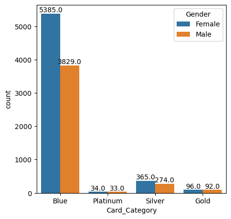

```python
plt.figure(figsize=(5, 5))
ax = sns.countplot(data=df, x="Card_Category", hue="Gender")
for p in ax.patches:
    height = p.get_height()
    ax.annotate(f'{height}', (p.get_x() + p.get_width() / 2., height),
                ha='center', va='center', fontsize=10, color='black', xytext=(0, 5),
                textcoords='offset points')
plt.show()
```

### This countplot shows that count of Male and Female by card-Category

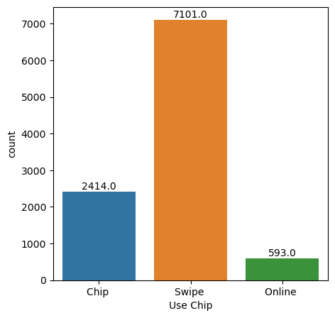

```python
plt.figure(figsize=(5, 5))
ax = sns.countplot(data=df, x="Use Chip")
for p in ax.patches:
    height = p.get_height()
    ax.annotate(f'{height}', (p.get_x() + p.get_width() / 2., height),
                ha='center', va='center', fontsize=10, color='black', xytext=(0, 5),
                textcoords='offset points')
plt.show()
```

### This countplot shows that count of payment-Modes

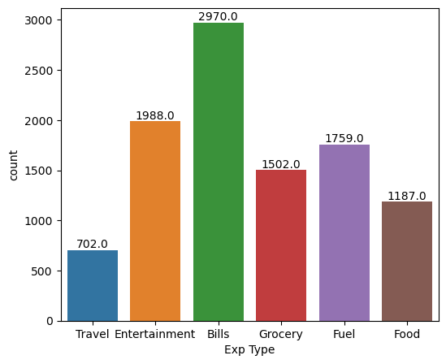

```python
plt.figure(figsize=(6, 5))
ax = sns.countplot(data=df, x="Exp Type")
for p in ax.patches:
    height = p.get_height()
    ax.annotate(f'{height}', (p.get_x() + p.get_width() / 2., height),
                ha='center', va='center', fontsize=10, color='black', xytext=(0, 5),
                textcoords='offset points')
plt.show()
```

### This Countplot shows that count of customer Expenditure paid by creditcard

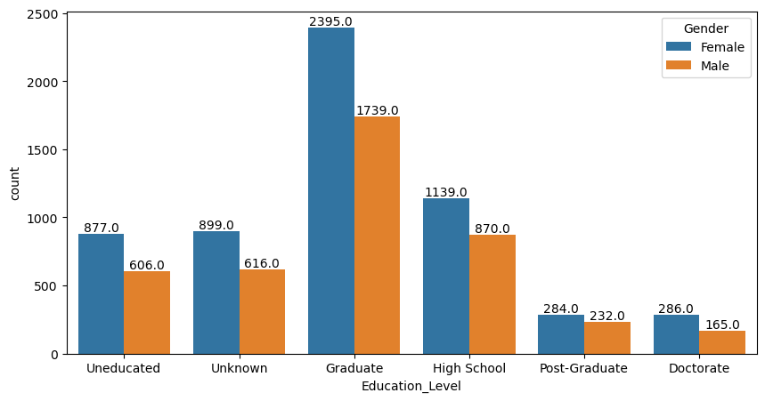

```python
plt.figure(figsize=(10, 5))
ax = sns.countplot(data=df, x="Education_Level",hue="Gender")
for p in ax.patches:
    height = p.get_height()
    ax.annotate(f'{height}', (p.get_x() + p.get_width() / 2., height),
                ha='center', va='center', fontsize=10, color='black', xytext=(0, 5),
                textcoords='offset points')
plt.show()
```

### This countplot shows that count of Education-level of Customers

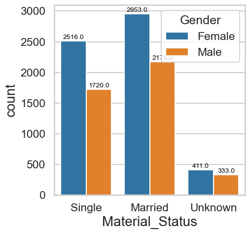

```python
plt.figure(figsize=(5, 5))
ax = sns.countplot(data=df, x="Material_Status",hue="Gender")
for p in ax.patches:
    height = p.get_height()
    ax.annotate(f'{height}', (p.get_x() + p.get_width() / 2., height),
                ha='center', va='center', fontsize=10, color='black', xytext=(0, 5),
                textcoords='offset points')
plt.show()
```

### This Countplot shows that Count of Marital-Status of Customers

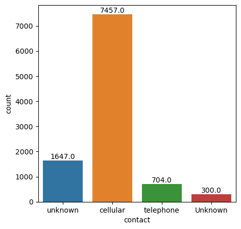

```python
plt.figure(figsize=(5, 5))
ax = sns.countplot(data=df, x="contact")
for p in ax.patches:
    height = p.get_height()
    ax.annotate(f'{height}', (p.get_x() + p.get_width() / 2., height),
                ha='center', va='center', fontsize=10, color='black', xytext=(0, 5),
                textcoords='offset points')
```

### This Countplot shows that Count of Customers contact

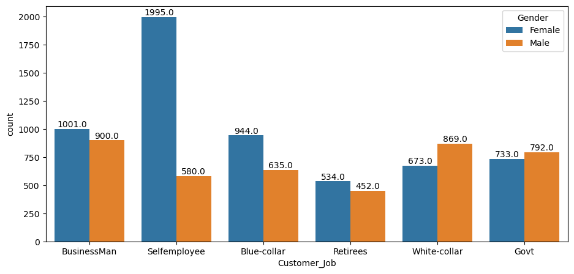

```python
plt.figure(figsize=(11, 5))
ax = sns.countplot(data=df, x="Customer_Job",hue="Gender")
for p in ax.patches:
    height = p.get_height()
    ax.annotate(f'{height}', (p.get_x() + p.get_width() / 2., height),
                ha='center', va='center', fontsize=10, color='black', xytext=(0, 5),
                textcoords='offset points')
```

### This countplot shows that count of Customer Occupations.

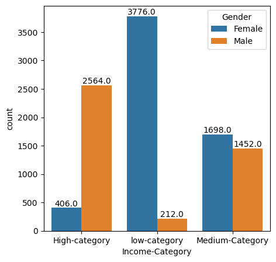

```python
plt.figure(figsize=(5, 5))
ax = sns.countplot(data=df, x="Income-Category",hue="Gender")
for p in ax.patches:
    height = p.get_height()
    ax.annotate(f'{height}', (p.get_x() + p.get_width() / 2., height),
                ha='center', va='center', fontsize=10, color='black', xytext=(0, 5),
                textcoords='offset points')
```

### This Countplot shows that count of customer income-category

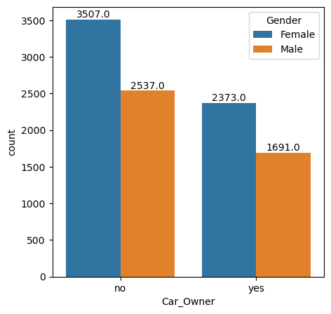

```python
plt.figure(figsize=(5, 5))
ax = sns.countplot(data=df, x="Car_Owner",hue="Gender")
for p in ax.patches:
    height = p.get_height()
    ax.annotate(f'{height}', (p.get_x() + p.get_width() / 2., height),
                ha='center', va='center', fontsize=10, color='black', xytext=(0, 5),
                textcoords='offset points')
```

### With the help of this countplot we can easily find the how many customers are car owners

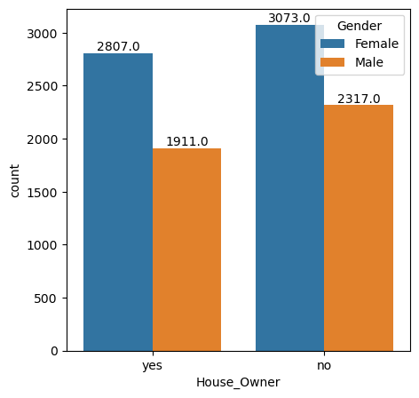

```python
plt.figure(figsize=(5, 5))
ax = sns.countplot(data=df, x="House_Owner",hue="Gender")
for p in ax.patches:
    height = p.get_height()
    ax.annotate(f'{height}', (p.get_x() + p.get_width() / 2., height),
                ha='center', va='center', fontsize=10, color='black', xytext=(0, 5),
                textcoords='offset points')
```

### With the help of this countplot we can easily find the how many customers are House owners

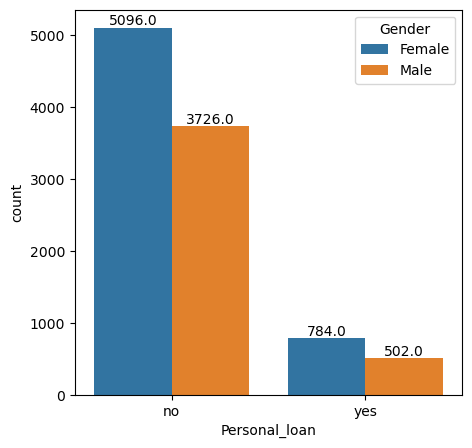

```python
plt.figure(figsize=(5, 5))
ax = sns.countplot(data=df, x="Personal_loan",hue="Gender")
for p in ax.patches:
    height = p.get_height()
    ax.annotate(f'{height}', (p.get_x() + p.get_width() / 2., height),
                ha='center', va='center', fontsize=10, color='black', xytext=(0, 5),
                textcoords='offset points')
```

### With the help of this countplot we can easily find the how many customers have given Personal loan.

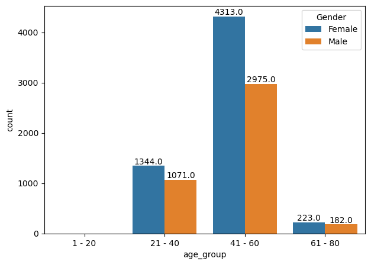

```python
plt.figure(figsize=(7, 5))
ax = sns.countplot(data=df, x="age_group",hue="Gender")
for p in ax.patches:
    height = p.get_height()
    ax.annotate(f'{height}', (p.get_x() + p.get_width() / 2., height),
                ha='center', va='center', fontsize=10, color='black', xytext=(0, 5),
                textcoords='offset points')
```

### This Countplot shows that Customers Age Group

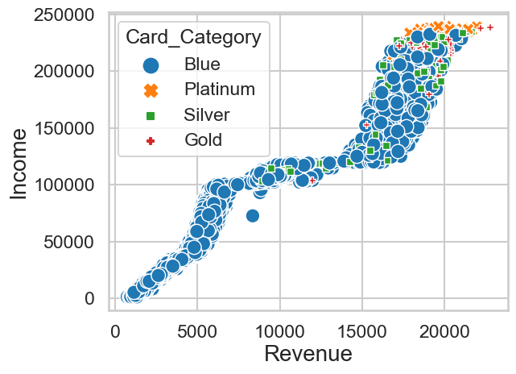

```python
sns.scatterplot(x="Revenue",y = "Income",data = df,hue = "Card_Category",style="Card_Category",size ="Card_Category")
```

## This Scatterplot shows that Income and Revenue by card Categories

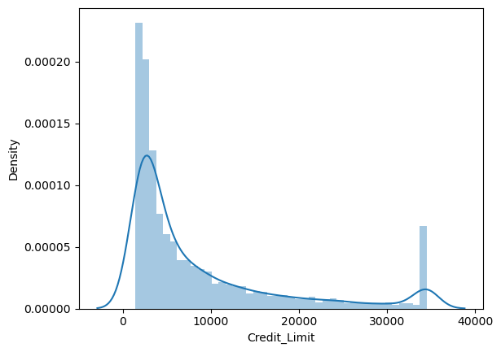

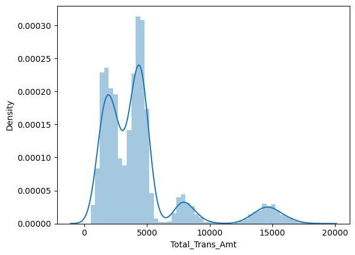

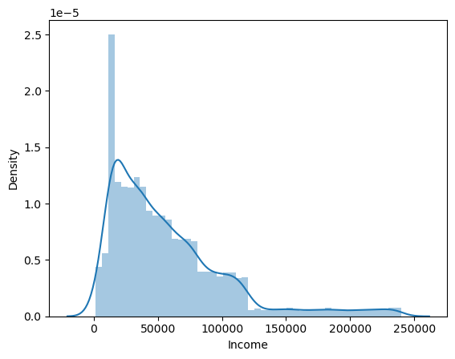

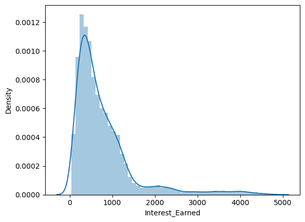

```python
for i in ["Credit_Limit","Total_Trans_Amt","Income","Interest_Earned"]:
    sns.distplot(df[i])
    plt.show()
```

### with the help of distplot we can find the density of Credit_Limit,Total_Trans_Amt,Income,Interest_Earned.

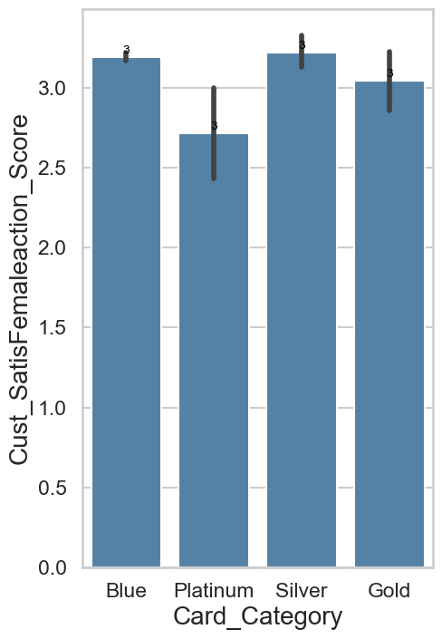

```python
plt.figure(figsize=(5, 8))
ax = sns.barplot(x ="Card_Category",y ="Cust_SatisFemaleaction_Score",data = df,color='steelblue')
for p in ax.patches:
    height = p.get_height()
    rounded_height = round(height)
    ax.annotate(f'{rounded_height}', (p.get_x() + p.get_width() / 2., height),
                ha='center', va='center', fontsize=10, color='black', xytext=(0, 5),
                textcoords='offset points')
plt.show()
```

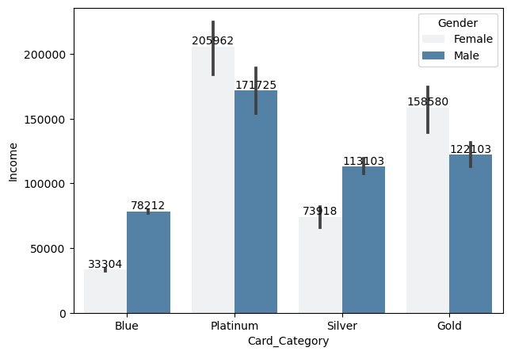

```python
plt.figure(figsize=(7, 5))
ax = sns.barplot(x ="Card_Category",y ="Income",data = df,hue ="Gender",color='steelblue')
for p in ax.patches:
    height = p.get_height()
    rounded_height = round(height)
    ax.annotate(f'{rounded_height}', (p.get_x() + p.get_width() / 2., height),
                ha='center', va='center', fontsize=10, color='black', xytext=(0, 5),
                textcoords='offset points')
plt.show()
```

## This Barplot shows that Income Received by Card-categories

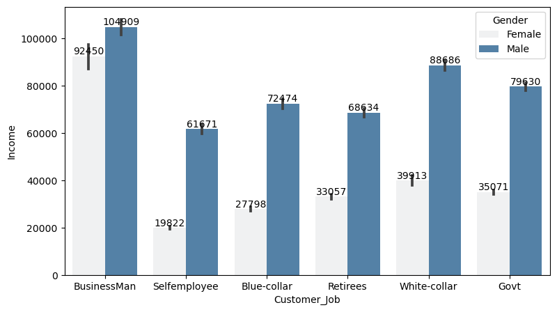

```python
plt.figure(figsize=(9, 5))
ax = sns.barplot(x ="Customer_Job",y ="Income",data = df,hue ="Gender",color='steelblue')
for p in ax.patches:
    height = p.get_height()
    rounded_height = round(height)
    ax.annotate(f'{rounded_height}', (p.get_x() + p.get_width() / 2., height),
                ha='center', va='center', fontsize=10, color='black', xytext=(0, 5),
                textcoords='offset points')
plt.show()
```

### This Barplot shoes that Customers job and their Income

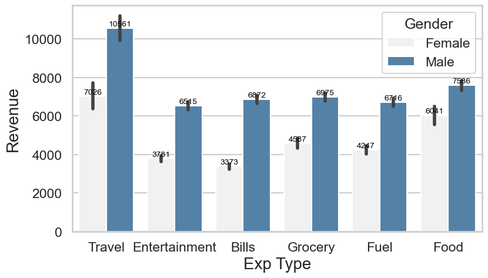

```python
plt.figure(figsize=(9, 5))
ax = sns.barplot(x ="Exp Type",y ="Revenue",data = df,hue ="Gender",color='steelblue')
for p in ax.patches:
    height = p.get_height()
    rounded_height = round(height)
    ax.annotate(f'{rounded_height}', (p.get_x() + p.get_width() / 2., height),
                ha='center', va='center', fontsize=10, color='black', xytext=(0, 5),
                textcoords='offset points')
plt.show()
```

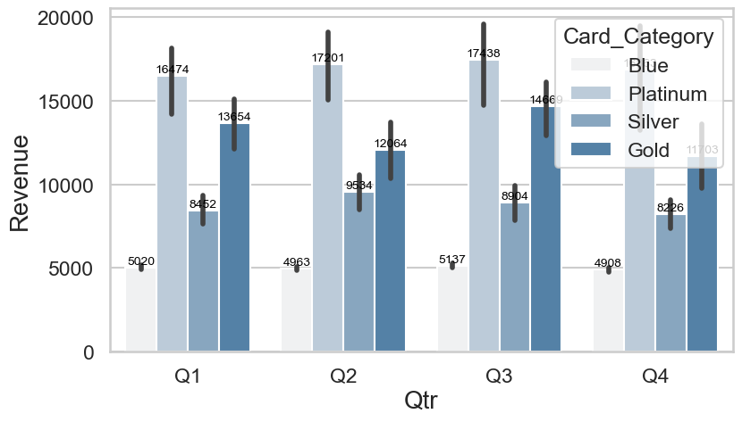

```python
plt.figure(figsize=(9, 5))
ax = sns.barplot(x ="Qtr",y ="Revenue",hue="Card_Category",data = df,color='steelblue')
for p in ax.patches:
    height = p.get_height()
    rounded_height = round(height)
    ax.annotate(f'{rounded_height}', (p.get_x() + p.get_width() / 2., height),
                ha='center', va='center', fontsize=10, color='black', xytext=(0, 5),
                textcoords='offset points')
plt.show()
```

### This Barplot shows that Quaterly Revnue by Card Type

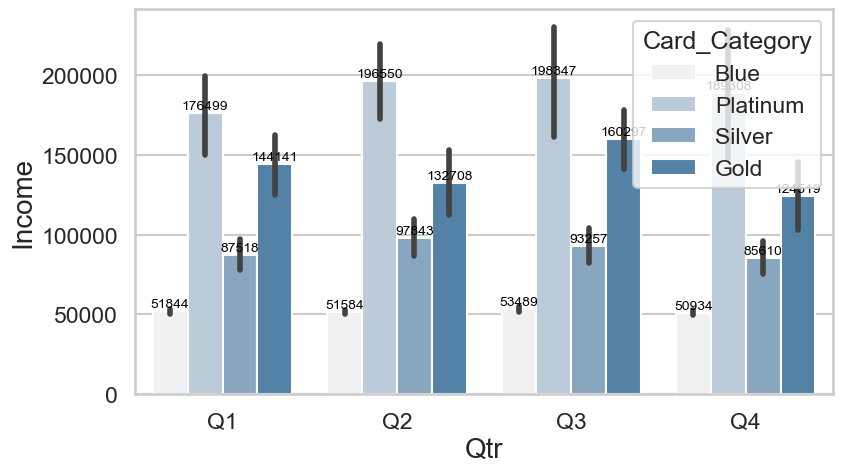

```python
plt.figure(figsize=(9, 5))
ax = sns.barplot(x ="Qtr",y ="Income",hue="Card_Category",data = df,color='steelblue')
for p in ax.patches:
    height = p.get_height()
    rounded_height = round(height)
    ax.annotate(f'{rounded_height}', (p.get_x() + p.get_width() / 2., height),
                ha='center', va='center', fontsize=10, color='black', xytext=(0, 5),
                textcoords='offset points')
plt.show()
```

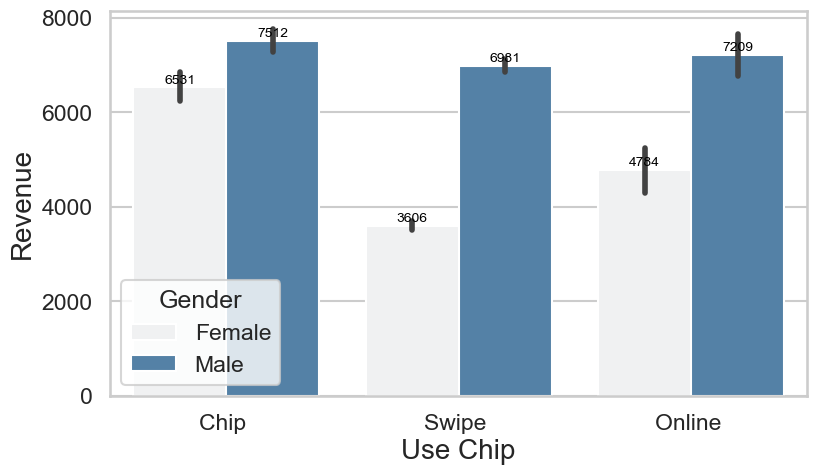

```python
plt.figure(figsize=(9, 5))
ax = sns.barplot(x ="Use Chip",y ="Revenue",hue="Gender",data = df,color='steelblue')
for p in ax.patches:
    height = p.get_height()
    rounded_height = round(height)
    ax.annotate(f'{rounded_height}', (p.get_x() + p.get_width() / 2., height),
                ha='center', va='center', fontsize=10, color='black', xytext=(0, 5),
                textcoords='offset points')
plt.show()
```

### This Barplot shows that Revenue from Use Chip by Customers

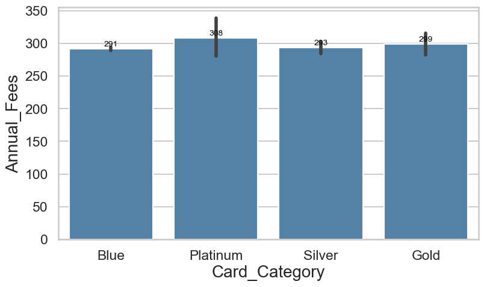

```python
plt.figure(figsize=(9, 5))
ax = sns.barplot(x ="Card_Category",y ="Annual_Fees",data = df,color='steelblue')
for p in ax.patches:
    height = p.get_height()
    rounded_height = round(height)
    ax.annotate(f'{rounded_height}', (p.get_x() + p.get_width() / 2., height),
                ha='center', va='center', fontsize=10, color='black', xytext=(0, 5),
                textcoords='offset points')
plt.show()
```

### This Barplot shows that Card-categories and their annual fees

[figure not shown]

```python
plt.figure(figsize=(9, 5))
ax = sns.barplot(x ="age_group",y ="Income",hue="Gender",data = df,color='steelblue')
for p in ax.patches:
    height = p.get_height()
    ax.annotate(f'{rounded_height}', (p.get_x() + p.get_width() / 2., height),
                ha='center', va='center', fontsize=10, color='black', xytext=(0, 5),
                textcoords='offset points')
plt.show()
```

## This barplot shows that customers age-group and their Inccome.

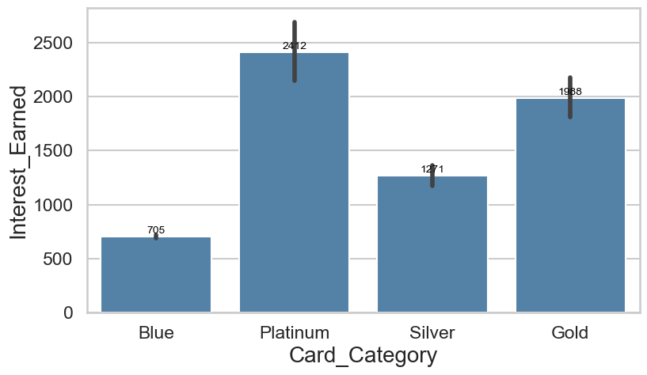

```python
plt.figure(figsize=(9, 5))
ax = sns.barplot(x ="Card_Category",y ="Interest_Earned",data = df,color='steelblue')
for p in ax.patches:
    height = p.get_height()
    rounded_height = round(height)
    ax.annotate(f'{rounded_height}', (p.get_x() + p.get_width() / 2., height),
                ha='center', va='center', fontsize=10, color='black', xytext=(0, 5),
                textcoords='offset points')
plt.show()
```

### This Barplot shows that Interest Earned by Card-Category

```python
a=df.select_dtypes(include="number").corr()
```

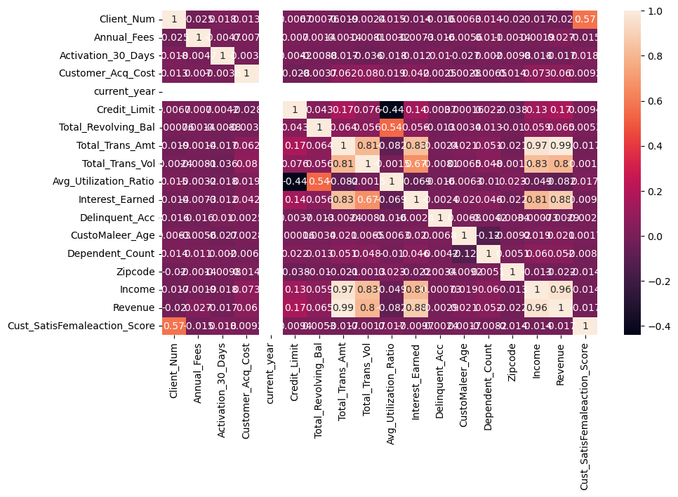

```python
plt.figure(figsize=(10,6))
sns.heatmap(a, annot=True)
```

## Conclusion:

By identifying distinct customer segments, businesses can tailor their marketing strategies, improving customer engagement and increasing the efficiency of marketing efforts. High-value customer segments can be targeted with personalized offers, leading to increased customer acquisition, retention, and loyalty.